# How Daily Activity Affects Step Count

## Introduction

This visual data story explores how my daily step count is related to activity type, weather conditions, and the way the data was collected. The data was collected through observational logging using a Google Form.

The main variable I am analysing is step count. I also recorded activity type and weather to explore possible factors that may influence how much I walked.

## Activity Type and Step Count

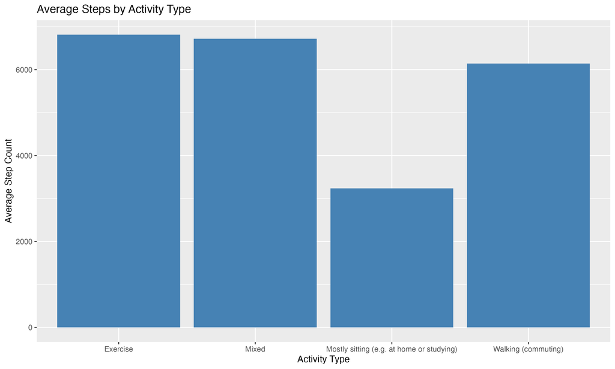

Bar chart showing the average step count for each activity type

This chart shows the average step count for each activity type. Exercise and mixed activity days had higher average step counts, while mostly sitting days had much lower average step counts.

This suggests that the type of daily activity has a clear relationship with step count.

## Weather and Step Count

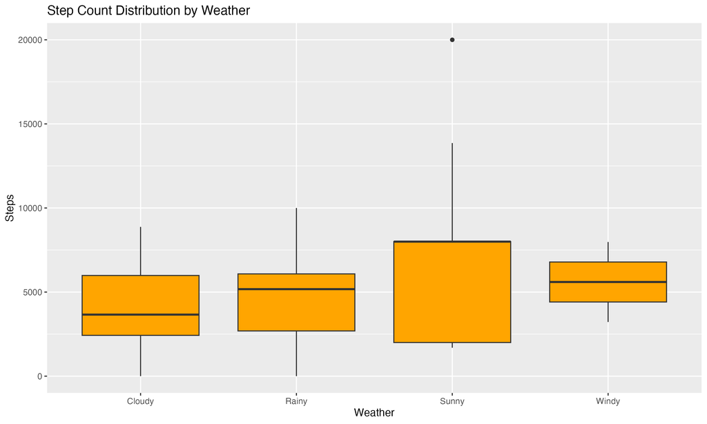

Boxplot showing the distribution of step counts for each weather condition

This boxplot compares step counts under different weather conditions. It shows the spread of step counts for sunny, cloudy, rainy, and windy days.

The results suggest that weather may have some influence on walking behaviour, but there is also variation within each weather category. For example, sunny days include a very high step count, which may be an unusual observation.

## Data Collection Over Time

[figure not shown]

## Conclusion

Overall, these visualisations suggest that step count is related to both behavioural factors, such as activity type, and environmental factors, such as weather.

The data also shows that the collection process matters. Since some observations were entered retrospectively, the results should be interpreted carefully.